# Embedded data stewardship

Embedded data stewardship and research intelligence

Five years of practice at a research group at ETH Zurich

Lars Schöbitz, Colin Walder, Adriana Clavijo Daza, Elizabeth Tilley

Global Health Engineering, ETH Zurich

Research Data Conference 2026, Bern, 19 November 2026

Both hands up

- Downdata support is not your main job
- Downa central service, a library, scientific IT
- Downfaculty or department level
- Still upinside one single research group

CHF

34,010,433

requested since 2021

81 proposals written, 23 funded

Why do we know this so exactly?

We keep data on our own group

- Proposalsevery one since 2021
- Peopletheses, student projects, positions
- GitHubrepositories and commits
- Downloadsour records on Zenodo
- ReachLinkedIn statistics, publications

Place a data steward inside the research group.

No doctorate.

No qualification in statistics.

No computer science degree.

An environmental engineer who likes computers.

Empathy, patience and persistence.

Fixed mindset

“I’m not good.”

Growth mindset

“I can learn.”

One to one. Workshops. Strategy. Motivation.

Voices from GHE

“People need to be reminded, and that works better with a personal relationship. I would never write an email to a central service: please help me organise my data.”

Jules, doctoral student

“You have sector specific knowledge. You know how to do lab experiments. Having the thematic background is very useful.”

Elizabeth, head of the group, to the data steward

The tools and the teaching come from inside the group

- 2021 to 2025Git taught one to one and in R courses
- 2025Claude Code introduced in the group
- 2026[**Git for Scientists**](https://gitforsci-ghe.github.io/website/), a workshop for the foundation
- 2026[**Agents for Scientists**](https://agentsforsci-ghe.github.io/website/), a workshop on coding agents
- 2027[**FAIR by Doing**](https://github.com/Global-Health-Engineering/fair-training), proposed for 15 ETH researchers

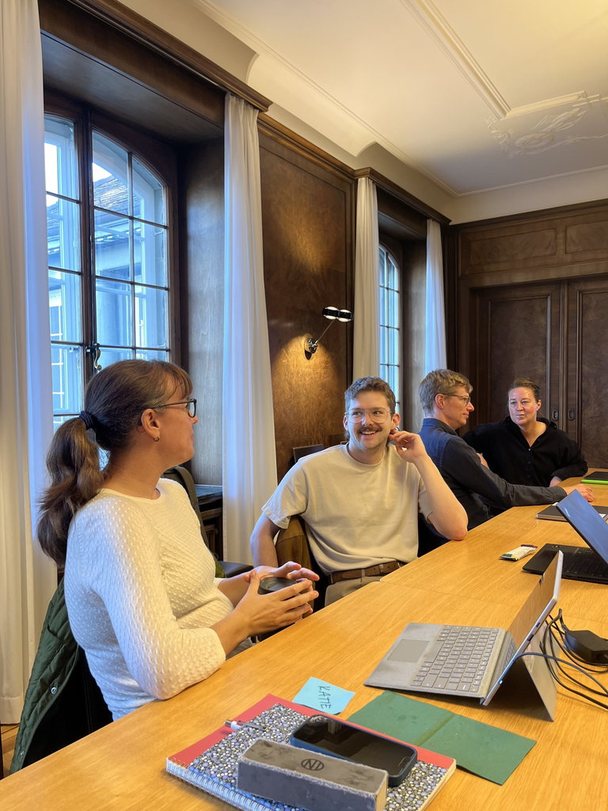

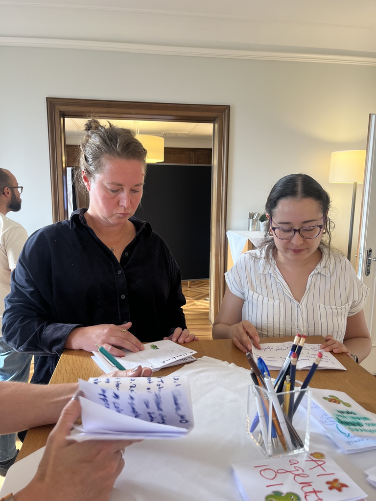

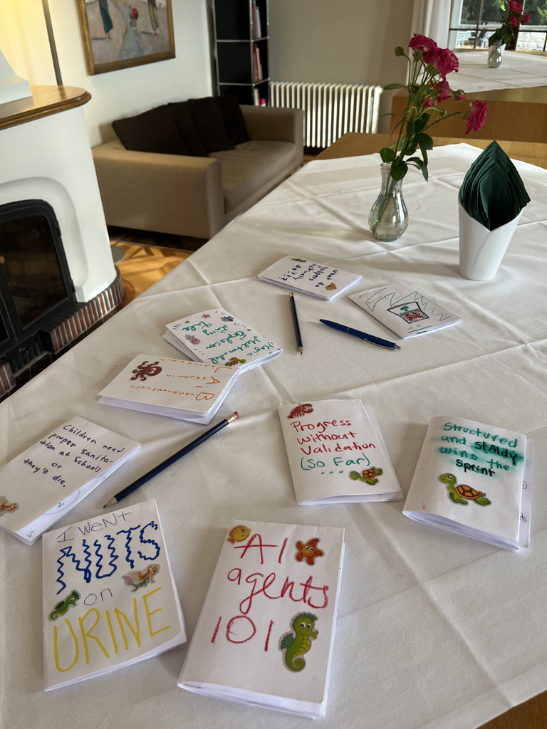

Keep data on your own group, and you

know what is going on.

GitHub activity as an indicator for competency?

“useful process indicators, but they are imperfect proxies for genuine competency”

A reviewer of one of our proposals, April 2026, on commits and repository counts

Keep data on your own group.Place a data steward inside it.Know what is going on.

What would you measure to show what data stewardship changes?

Thank you

Embedded data stewardship and research intelligence: five years of practice at a research group at ETH Zurich

[**Git for Scientists**](https://gitforsci-ghe.github.io/website/)  
Workshop tomorrow, Friday 20 November, 09:30, room Wytsicht

Lars Schöbitz, Colin Walder, Adriana Clavijo Daza, Elizabeth Tilley  
Global Health Engineering, ETH Zurich

Declaration of AI use  
[**rdc-2026/talk/AI-USE.md**](https://github.com/Global-Health-Engineering/rdc-2026/blob/main/talk/AI-USE.md)

The data package ghedata  
[**github.com/Global-Health-Engineering/ghedata**](https://github.com/Global-Health-Engineering/ghedata)

These slides  
[**github.com/Global-Health-Engineering/rdc-2026**](https://github.com/Global-Health-Engineering/rdc-2026)

Lars Schöbitz  
[**github.com/larnsce**](https://github.com/larnsce)  
[**linkedin.com/in/larsschoebitz**](https://www.linkedin.com/in/larsschoebitz)  
Newsletter (German and English): [**buttondown.com/bitz**](https://buttondown.com/bitz)

Figures: ghedata, November 2026.